# Healthcare Intel Digest

**Week of August 31, 2026**Market data through: August 28, 2026Narrative created: August 31, 2026

Weekly review of healthcare services, technology, distribution, and diagnostic company performance, changes, earnings activity, and strategy narrative.

## In the News

### Executive View

- **Medicare Advantage coding liability moved decisively beyond the plan.** The Villages Health System’s $541.5 million False Claims Act settlement shows that capitated provider groups can face enterprise-threatening exposure for unsupported diagnoses, while MA organizations remain responsible for returning resulting overpayments.
- **CMS supplied concrete evidence that payment integrity is shifting toward prepayment intervention.** Its laboratory initiative used claims analytics, provider revocations and payment suspensions to stop or recover an agency-reported $1.6 billion, expanding the addressable market for action-oriented fraud platforms while increasing cash-flow risk for flagged providers.
- **The No Surprises Act exposure is potentially much larger than previously understood.** A new, disputed Georgetown estimate attributes $22.4 billion of incremental 2022–2025 cost to federal dispute resolution. Even if the model overstates the amount, CMS data show that dispute volume and awards are growing fast enough to affect commercial pricing and network strategy.
- **Veeva’s CRM transition is increasingly a competitive migration rather than a defensive replacement cycle.** New enterprise commitments, more than 180 live customers and early adoption of embedded agents strengthen the case for domain-specific platforms that combine applications, data and AI.
- **Overall environment: modestly deteriorated for payer and delegated-provider compliance economics, while improving for payment-integrity, IDR and domain-specific automation vendors.**

### 1. The Villages settlement makes delegated coding risk an enterprise-level liability

**Status:** NEW

**What happened**

On August 26, the Department of Justice announced that The Villages Health System agreed to a $541.5 million settlement resolving self-disclosed allegations that it submitted unsupported or improperly amended diagnoses to Humana, UnitedHealthcare and Florida Blue from 2020 through 2024. Because the provider is in Chapter 11, the amount is an allowed, nondischargeable claim against its bankruptcy estate—not a $541.5 million cash recovery. MAO refunds reduce that claim.

Associated agreements call for UnitedHealthcare to pay approximately $125.5 million and Florida Blue to receive credit for $9.2 million of prior corrections and pay another $12.0 million, subject to effectiveness conditions. United’s agreement was coordinated with a CMS letter excluding certain affected members from applicable RADV samples and repayment calculations. A reliable public Humana repayment amount is unavailable. The settlement resolves allegations and is not an admission of liability. [DOJ, “The Villages Health System LLC Agrees to $541.5M Settlement,” August 26, 2026](https://www.justice.gov/opa/pr/villages-health-system-llc-agrees-5415m-settlement-resolve-false-claims-act-allegations); [DOJ/CMS, “UHG DOJ Agreement,” executed July 29, 2026](https://www.justice.gov/opa/media/1459296/dl). ([justice.gov](https://www.justice.gov/opa/pr/villages-health-system-llc-agrees-5415m-settlement-resolve-false-claims-act-allegations?utm_source=openai))

**Implication**

The enforcement perimeter now clearly reaches both sides of delegated-risk contracts. Provider organizations face FCA, repayment and solvency exposure; MAOs remain exposed to CMS even when the diagnosis originated with a contracted provider.

Near-term demand should shift from maximizing code capture toward defensible evidence lineage: rendering-provider approval, amendment timestamps, source-document provenance, code-deletion workflows and reconciliation between provider, plan and CMS systems. Contracts will receive greater scrutiny around indemnification, audit rights, repayment reserves and access to underlying records. Pure coding-yield vendors face higher risk unless they can demonstrate controls that survive retrospective review.

**Watch next**

Humana’s repayment mechanics; whether DOJ uses similar provider self-disclosures to pursue additional MAOs; and whether plans tighten delegated-provider coding contracts before the 2027 payment year.

### 2. CMS is converting fraud analytics into prepayment operating controls

**Status:** NEW

**What happened**

CMS reported on August 28 that its laboratory enforcement actions had stopped or recovered more than $1.6 billion in potentially improper Medicare payments. The agency attributed $732 million to revoking 157 providers, more than $500 million to 185 payment suspensions, $276 million to recovered overpayments and $127 million to contractor-generated law-enforcement referrals.

CMS said it used AI and machine-learning models to identify unusual claims, documentation, ordering and provider-relationship patterns, followed by claim holds, denials, suspensions or revocations. These are agency-reported prevention and recovery figures, not a single independently audited savings measure. [CMS, “CMS Prevents $1.6 Billion in Fraudulent Medicare Laboratory Payments,” August 28, 2026](https://www.cms.gov/newsroom/press-releases/cms-prevents-1-6-billion-fraudulent-medicare-laboratory-payments). ([cms.gov](https://www.cms.gov/newsroom/press-releases/cms-prevents-1-6-billion-fraudulent-medicare-laboratory-payments))

**Implication**

This extends the earlier Medicaid “war room” thesis into Medicare fee-for-service and shows that the valuable product is not merely a detection model. It is an operating system connecting anomaly identification to enrollment review, prepayment edits, suspension, investigation and recoupment.

Payment-integrity vendors should expect buyers to demand measurable prevented dollars, low false-positive rates and rapid case disposition. Laboratories and other high-scrutiny providers face greater working-capital volatility because payment suspensions can precede a final liability determination. The strongest platforms will therefore combine detection with explainability, investigation workflow and provider-response management.

**Watch next**

Whether CMS publishes denominator data, false-positive or appeal outcomes, and comparable prepayment results for hospice, skin substitutes and durable medical equipment.

### 3. New IDR estimates raise the economic stakes of the No Surprises litigation

**Status:** UPDATE

**What happened**

Georgetown researchers estimated that federal No Surprises Act dispute resolution generated $22.4 billion of incremental cost from 2022 through 2025: $15.6 billion in awards above comparable in-network rates, $4.2 billion in internal administrative expense and $2.7 billion in process fees. They estimated $16.6 billion occurred in 2025 alone.

Underlying CMS data show 2.6 million disputes initiated in 2025, up 77%, with providers winning approximately 85% and receiving a median award above four times the qualifying payment amount. First-half 2026 filings reached 1.75 million, 50% above the prior-year period. The $22.4 billion figure is a modeled estimate rather than a CMS spending total; specialty-provider groups dispute its use of the QPA as the counterfactual market price and its administrative-cost assumptions. [Health Affairs, “Spending on IDR Process Pushes No Surprises Act Costs to More Than $22.4 Billion,” August 26, 2026](https://www.healthaffairs.org/content/forefront/spending-idr-process-pushes-no-surprises-act-costs-more-than-22-4-billion-over-just); [CMS, “Independent Dispute Resolution Reports,” updated July 22, 2026](https://www.cms.gov/initiatives/no-surprise-billing/overview/policies-resources/independent-dispute-resolution-reports). ([chir.georgetown.edu](https://chir.georgetown.edu/spending-on-idr-process-pushes-no-surprises-act-costs-to-more-than-22-4-billion-over-just-four-years/))

**Implication**

Last week’s court-driven uncertainty over QPA methodology now has a much larger potential economic range. Commercial plans and self-funded employers face upward pressure from awards, administration and negotiating leverage; providers with scaled IDR capabilities retain a meaningful cash-recovery channel.

Demand should rise for eligibility screening, batching, offer optimization, contract-rate intelligence and award collection. However, vendors and providers should not capitalize current outcomes indefinitely: the magnitude of the estimate increases the probability of congressional or administrative intervention.

**Watch next**

Implementation of the May 2026 IDR operations rule, revised QPA guidance following litigation and evidence that 2026 dispute growth slows—or continues despite operational reforms.

### 4. Veeva’s quarter strengthens the domain-platform thesis

**Status:** UPDATE

**What happened**

Veeva reported August 26 quarterly revenue of $928 million, up 18%, including subscription revenue of $766.8 million, up 16%. More strategically, Vault CRM surpassed 180 live customers, including five top-20 biopharma companies. Veeva said August commitments brought its total to 12 of the top 20, while Biogen and Regeneron separately announced global Vault CRM selections on August 25. Falcon, its agentic labor platform for clinical, regulatory and safety operations, has five early adopters with initial go-lives planned this year.

[Veeva, “Fiscal 2027 Second Quarter Results,” August 26, 2026](https://ir.veeva.com/news/news-details/2026/Veeva-Announces-Fiscal-2027-Second-Quarter-Results/default.aspx); [Veeva, “Vault CRM Selected by Biogen,” August 25, 2026](https://ir.veeva.com/news/news-details/2026/Veeva-Vault-CRM-Selected-by-Biogen/default.aspx); [Veeva, “Vault CRM Selected by Regeneron,” August 25, 2026](https://ir.veeva.com/news/news-details/2026/Veeva-Vault-CRM-Selected-by-Regeneron/default.aspx). ([ir.veeva.com](https://ir.veeva.com/news/news-details/2026/Veeva-Announces-Fiscal-2027-Second-Quarter-Results/default.aspx?utm_source=openai))

**Implication**

This was more than a beat-and-raise. The print reduces uncertainty that customers would resist migrating from Veeva’s legacy Salesforce-based product and supports a platform strategy combining regulated workflows, proprietary data and embedded agents.

The competitive lesson extends beyond life sciences: vertical AI is gaining leverage where the incumbent controls workflow, data semantics and compliance. Falcon remains early, however; customer commitments do not yet establish production reliability, labor displacement or measurable return on investment.

**Watch next**

Falcon’s first production deployments, quantified cycle-time or labor outcomes, and whether CRM commitments translate into adoption of adjacent data, content and consulting products.

### What I'm Watching Next

- **September 15, 2026:** Aetna’s initial Medicare Advantage commission changes take effect; [NCQA Health Plan Ratings](https://www.ncqa.org/hedis/reports-and-research/health-plan-ratings/) are scheduled for release.
- **October 15, 2026:** Medicare annual enrollment begins, providing the first demand test for noncommissionable MA plans.
- **January 1, 2027:** Principal [CMS-0057 payer API requirements](https://www.cms.gov/newsroom/fact-sheets/cms-interoperability-prior-authorization-final-rule-cms-0057-f) take effect. ([cms.gov](https://www.cms.gov/newsroom/fact-sheets/cms-interoperability-prior-authorization-final-rule-cms-0057-f?utm_source=openai))

### Bottom Line

The week’s most important change is the Villages settlement: unsupported MA diagnoses can create simultaneous provider solvency risk, payer repayment exposure and RADV complexity. Delegated-provider coding governance therefore requires the closest attention. The next scheduled catalyst is September 15, when quality ratings and Aetna’s distribution changes will provide new evidence on 2027 MA revenue and enrollment positioning.

## Notable Changes

Comparison with the final report dated August 24, 2026 (market data through August 21, 2026).

### Sectors

#### Top-three comparison

| Entity | Previous | Current | Change | Current return |
| --- | --- | --- | --- | --- |
| Precision Diagnostics | #1 | #1 | — 0 | +84.5% |
| Inpatient Non-Acute Providers | #2 | #2 | — 0 | +64.0% |
| Value-Based Care | #3 | #3 | — 0 | +52.6% |

### Stocks

#### Top-three comparison

| Entity | Previous | Current | Change | Current return |
| --- | --- | --- | --- | --- |
| 10x Genomics (TXG) | #1 | #1 | — 0 | +339.3% |
| PACS Group (PACS) | #2 | #2 | — 0 | +267.3% |
| Agilon Health (AGL) | #3 | #3 | — 0 | +189.2% |

#### Largest rank changes

| Entity | Previous | Current | Change | Current return |
| --- | --- | --- | --- | --- |
| P3 Health (PIII) | #22 | #39 | ↓ 17 | +10.7% |
| Veeva Systems (VEEV) | #62 | #49 | ↑ 13 | +2.8% |
| Omada Health (OMDA) | #42 | #53 | ↓ 11 | +0.0% |

### Subcategory movement since the previous report

| Subcategory | Move | Last Report, 12m Ret | Current Report, 12m Ret |
| --- | --- | --- | --- |
| Health IT and Data | +3.4% | -28.5% | -23.3% |
| Pharma Distribution | +2.7% | +27.6% | +31.3% |
| Payers | +0.3% | +28.3% | +27.5% |
| Outpatient and Home Providers | -0.0% | +41.0% | +44.2% |
| Health Care Real Estate | -0.8% | +37.9% | +34.5% |
| Inpatient Non-Acute Providers | -1.6% | +64.6% | +64.0% |
| Precision Diagnostics | -2.4% | +93.1% | +84.5% |
| Value-Based Care | -2.9% | +57.9% | +52.6% |
| Health System Providers | -3.1% | +13.5% | +9.5% |
| Digital Health, Specialty, Benefits | -6.5% | +9.8% | +4.3% |

### Largest company moves

| Direction | Company | Ticker | Move |
| --- | --- | --- | --- |
| Gain | Definitive Healthcare | DH | +12.4% |
| Gain | Veeva Systems | VEEV | +11.6% |
| Gain | NeoGenomics | NEO | +6.3% |
| Decline | Hims & Hers | HIMS | -14.6% |
| Decline | Tempus AI | TEM | -11.9% |
| Decline | P3 Health | PIII | -10.6% |

## Subcategory Performance

| Subcategory | Companies | Market cap | 3m Return | 12m Return | 24m Return |
| --- | --- | --- | --- | --- | --- |
| Payers | 10 | $769.8B | +4.6% | +27.5% | -10.4% |
| Health System Providers | 5 | $119.8B | +18.2% | +9.5% | +11.4% |
| Inpatient Non-Acute Providers | 4 | $31.4B | +11.9% | +64.0% | +11.3% |
| Health Care Real Estate | 8 | $266.4B | +11.7% | +34.5% | +72.2% |
| Value-Based Care | 5 | $7.2B | -0.4% | +52.6% | -10.8% |
| Outpatient and Home Providers | 11 | $64.8B | +10.2% | +44.2% | +85.4% |
| Digital Health, Specialty, Benefits | 10 | $26.3B | +13.1% | +4.3% | +42.2% |
| Health IT and Data | 12 | $470.6B | -17.6% | -23.3% | +8.5% |
| Pharma Distribution | 5 | $222.6B | +19.4% | +31.3% | +62.7% |
| Precision Diagnostics | 12 | $168.6B | +34.5% | +84.5% | +147.0% |

Subcategory returns use the most recently saved market capitalizations as weights.

## Stock Performance vs. SPY

The same selected stocks appear in every chart. Each line is labeled at the right with its ticker and return for the displayed window.

### Last 6 months

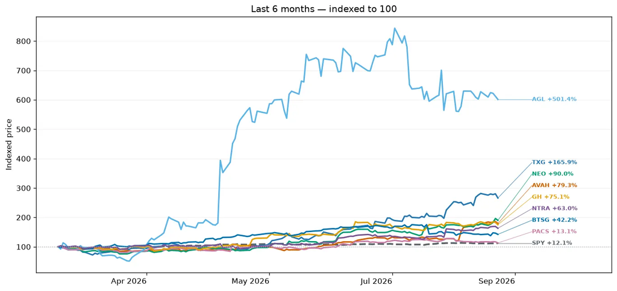

### Last 12 months

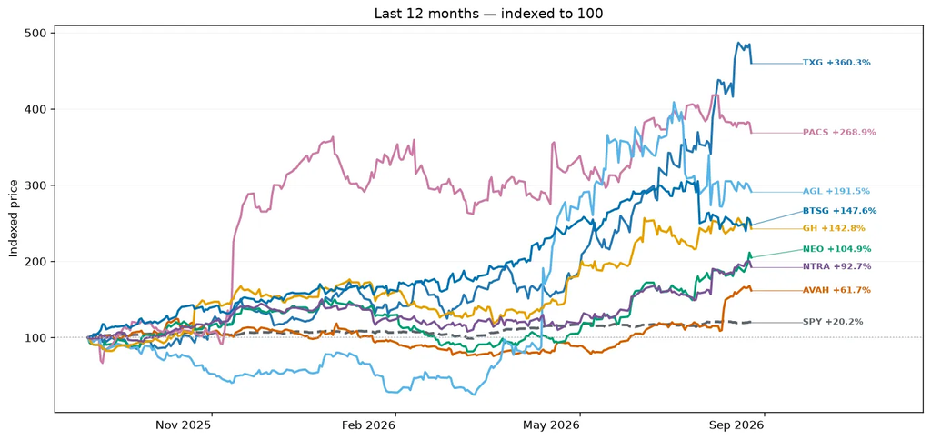

### Last 24 months

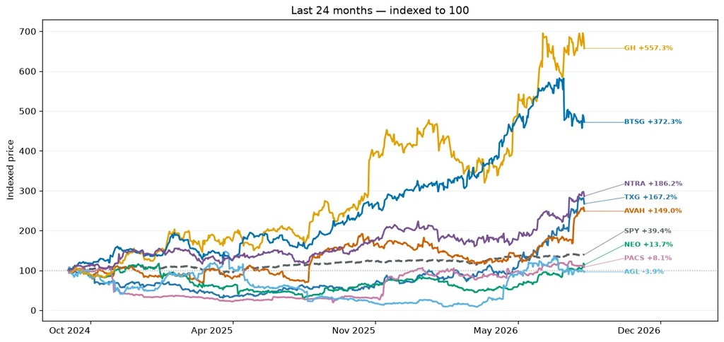

## Current Top Stocks

### Last 3 months

| Rank | Company | Ticker | Market cap | Return |
| --- | --- | --- | --- | --- |
| 1 | 10x Genomics | TXG | $6.1B | +117.4% |
| 2 | Aveanna Healthcare | AVAH | $2.0B | +85.8% |
| 3 | NeoGenomics | NEO | $2.1B | +71.6% |
| 4 | Lifestance Health | LFST | $4.0B | +59.7% |
| 5 | Veeva Systems | VEEV | $33.1B | +58.7% |

### Last 12 months

| Rank | Company | Ticker | Market cap | Return |
| --- | --- | --- | --- | --- |
| 1 | 10x Genomics | TXG | $6.1B | +339.3% |
| 2 | PACS Group | PACS | $7.3B | +267.3% |
| 3 | Agilon Health | AGL | $2.1B | +189.2% |
| 4 | BrightSpring Health Services | BTSG | $12.4B | +149.6% |
| 5 | Guardant Health | GH | $21.4B | +139.5% |

### Last 24 months

| Rank | Company | Ticker | Market cap | Return |
| --- | --- | --- | --- | --- |
| 1 | Guardant Health | GH | $21.4B | +531.4% |
| 2 | BrightSpring Health Services | BTSG | $12.4B | +371.2% |
| 3 | Natera | NTRA | $39.4B | +175.9% |
| 4 | 10x Genomics | TXG | $6.1B | +163.6% |
| 5 | Talkspace | TALK | $874.4M | +162.5% |

## Companies by Subcategory

### PayersLast 3m: +4.6%

| Company | Ticker | Market cap | 3m Return | 12m Return | 24m Return |
| --- | --- | --- | --- | --- | --- |
| UnitedHealth | UNH | $380.1B | +3.3% | +26.8% | -33.4% |
| CVS Health | CVS | $135.1B | +2.3% | +27.2% | +62.6% |
| Humana | HUM | $43.7B | +26.2% | +27.0% | +8.8% |
| Oscar Health | OSCR | $9.4B | +37.1% | +82.9% | +66.5% |
| Molina Healthcare | MOH | $10.2B | +15.2% | +10.6% | -42.8% |
| Cigna | CI | $73.7B | +0.5% | -7.3% | -22.9% |
| Elevance | ELV | $81.5B | +0.3% | +23.8% | -29.2% |
| Clover Health | CLOV | $2.2B | +6.3% | +61.5% | +60.8% |
| Centene | CNC | $30.7B | +8.6% | +123.0% | -17.9% |
| Alignment Health | ALHC | $3.1B | -11.1% | -16.7% | +51.2% |

### Health System ProvidersLast 3m: +18.2%

| Company | Ticker | Market cap | 3m Return | 12m Return | 24m Return |
| --- | --- | --- | --- | --- | --- |
| HCA Healthcare | HCA | $87.2B | +10.4% | +3.4% | +5.6% |
| Tenet Health | THC | $20.5B | +52.2% | +44.7% | +60.9% |
| Universal Health Services | UHS | $10.2B | +17.5% | -5.5% | -27.9% |
| Community Health Systems | CYH | $417.4M | +7.7% | +6.2% | -46.2% |
| Ardent Health Partners | ARDT | $1.5B | +18.7% | -13.6% | -44.7% |

### Inpatient Non-Acute ProvidersLast 3m: +11.9%

| Company | Ticker | Market cap | 3m Return | 12m Return | 24m Return |
| --- | --- | --- | --- | --- | --- |
| The Ensign Group | ENSG | $10.4B | +3.2% | +0.7% | +14.3% |
| Acadia Healthcare | ACHC | $2.8B | +23.1% | +24.3% | -65.2% |
| Encompass Health | EHC | $11.0B | +14.2% | -0.7% | +29.9% |
| PACS Group | PACS | $7.3B | +16.6% | +267.3% | +7.8% |

### Health Care Real EstateLast 3m: +11.7%

| Company | Ticker | Market cap | 3m Return | 12m Return | 24m Return |
| --- | --- | --- | --- | --- | --- |
| Healthpeak properties | DOC | $15.1B | +9.5% | +16.8% | -5.9% |
| Ventas, Inc | VTR | $48.0B | +8.8% | +34.9% | +47.8% |
| Medical Properties Trust | MPT | $2.8B | -20.0% | — | — |
| National Health Investors | NHI | $3.7B | -1.7% | -8.0% | -11.5% |
| Omega Healthcare Investors | OHI | $15.1B | -1.6% | +8.0% | +16.3% |
| Welltower | WELL | $166.9B | +15.9% | +41.5% | +97.3% |
| CareTrust REIT | CTRE | $9.6B | -4.4% | +13.4% | +30.6% |
| Sabra Health Care REIT | SBRA | $5.3B | +3.6% | +7.8% | +21.0% |

### Value-Based CareLast 3m: -0.4%

| Company | Ticker | Market cap | 3m Return | 12m Return | 24m Return |
| --- | --- | --- | --- | --- | --- |
| Privia Health Group | PRVA | $3.0B | -3.3% | -9.8% | +3.2% |
| Astrana Health | ASTH | $1.8B | +0.9% | +18.8% | -20.6% |
| Agilon Health | AGL | $2.1B | +0.3% | +189.2% | -9.3% |
| Evolent Health | EVH | $347.6M | +16.5% | -52.3% | -85.6% |
| P3 Health | PIII | $32.7M | -24.3% | +10.7% | -63.5% |

### Outpatient and Home ProvidersLast 3m: +10.2%

| Company | Ticker | Market cap | 3m Return | 12m Return | 24m Return |
| --- | --- | --- | --- | --- | --- |
| Davita | DVA | $15.4B | -7.0% | +31.2% | +19.7% |
| Fresenius | FMS | $13.8B | +7.1% | -10.1% | +19.1% |
| Surgery Partners | SGRY | $2.0B | +2.5% | -39.7% | -57.2% |
| Option Care Health | OPCH | $3.4B | +14.5% | -16.7% | -25.4% |
| Lifestance Health | LFST | $4.0B | +59.7% | +124.6% | +95.1% |
| Chemed (Vitas) | CHE | $7.1B | +22.7% | +14.3% | -10.7% |
| Addus HomeCare | ADUS | $2.1B | +26.0% | +0.3% | -13.1% |
| Pennant Group | PNTG | $1.3B | +8.3% | +54.4% | +8.2% |
| US Physical Therapy | USPH | $1.2B | +22.4% | -5.1% | -8.1% |
| BrightSpring Health Services | BTSG | $12.4B | -4.1% | +149.6% | +371.2% |
| Aveanna Healthcare | AVAH | $2.0B | +85.8% | +66.5% | +135.8% |

### Digital Health, Specialty, BenefitsLast 3m: +13.1%

| Company | Ticker | Market cap | 3m Return | 12m Return | 24m Return |
| --- | --- | --- | --- | --- | --- |
| Teladoc | TDOC | $1.2B | -14.6% | -15.9% | -9.3% |
| Amwell | AMWL | $179.6M | +21.4% | +72.9% | +43.7% |
| Talkspace | TALK | $874.4M | +1.0% | +97.4% | +162.5% |
| Hims & Hers | HIMS | $6.4B | +10.3% | -31.9% | +95.8% |
| LifeMD | LFMD | $169.3M | -26.6% | -49.3% | -39.7% |
| Omada Health | OMDA | $1.2B | +31.8% | +0.0% | — |
| GoodRx | GDRX | $1.0B | +20.9% | -18.9% | -55.3% |
| Progyny | PGNY | $2.5B | +1.7% | +9.8% | +10.7% |
| Concentra Group | CON | $4.0B | +37.8% | +43.9% | +40.1% |
| HealthEquity | HQY | $8.8B | +9.5% | +7.9% | +21.1% |

### Health IT and DataLast 3m: -17.6%

| Company | Ticker | Market cap | 3m Return | 12m Return | 24m Return |
| --- | --- | --- | --- | --- | --- |
| Oracle-Cerner | ORCL | $374.1B | -33.2% | -33.3% | +6.8% |
| Veradigm | MDRX | n/a | -4.0% | -2.0% | -51.8% |
| Waystar | WAY | $4.0B | +31.8% | -30.7% | -3.6% |
| Solventum | SOLV | $13.6B | +21.6% | +24.7% | +42.1% |
| Phreesia | PHR | $663.2M | +23.2% | -61.6% | -52.7% |
| Consensus Cloud Solutions | CCSI | $669.7M | +10.6% | +43.0% | +57.7% |
| Definitive Healthcare | DH | $85.5M | -13.8% | -80.1% | -82.9% |
| Iqvia | IQV | $38.7B | +43.7% | +37.2% | +4.1% |
| Health Catalyst | HCAT | $154.4M | +15.2% | -53.1% | -77.9% |
| Doximity | DOCS | $3.8B | +24.9% | -60.7% | -27.3% |
| Veeva Systems | VEEV | $33.1B | +58.7% | +2.8% | +27.8% |
| Omnicell | OMCL | $1.7B | -25.1% | +1.5% | -25.6% |

### Pharma DistributionLast 3m: +19.4%

| Company | Ticker | Market cap | 3m Return | 12m Return | 24m Return |
| --- | --- | --- | --- | --- | --- |
| McKesson | MCK | $97.2B | +20.3% | +30.1% | +59.2% |
| Cardinal Health | CAH | $54.7B | +19.2% | +57.6% | +108.1% |
| Cencora | COR | $59.6B | +19.6% | +10.4% | +34.4% |
| Accendra Health | AHCO | $912.9M | -42.8% | -39.0% | -47.3% |
| Henry Schein | HSIC | $10.2B | +16.9% | +28.7% | +26.9% |

### Precision DiagnosticsLast 3m: +34.5%

| Company | Ticker | Market cap | 3m Return | 12m Return | 24m Return |
| --- | --- | --- | --- | --- | --- |
| Natera | NTRA | $39.4B | +46.1% | +93.9% | +175.9% |
| NeoGenomics | NEO | $2.1B | +71.6% | +105.6% | +9.3% |
| BillionToOne | BLLN | $6.5B | -5.8% | — | — |
| Guardant Health | GH | $21.4B | +24.5% | +139.5% | +531.4% |
| Tempus AI | TEM | $8.5B | +26.9% | -15.6% | +7.8% |
| Illumina | ILMN | $30.7B | +32.3% | +115.7% | +64.1% |
| 10x Genomics | TXG | $6.1B | +117.4% | +339.3% | +163.6% |
| PacBio | PACB | $447.3M | -6.0% | +6.9% | +2.2% |
| QuidelOrtho | QDEL | $1.2B | +13.2% | -48.6% | -65.1% |
| Quest Diagnostics | DGX | $25.8B | +24.6% | +33.6% | +54.7% |
| Labcorp Holdings | LH | $25.3B | +28.9% | +20.5% | +45.8% |
| Certara | CERT | $1.2B | +43.5% | -23.0% | -31.8% |

## Upcoming Earnings

### Health IT and Data

| Company | Ticker | Date | Market cap | 3m Return | 12m Return |
| --- | --- | --- | --- | --- | --- |
| Phreesia | PHR | September 2, 2026 | $663.2M | +23.2% | -61.6% |

## Recent Earnings Highlights — 3m Ret

Companies covered in this section:

- Veeva Systems (VEEV)
- HealthEquity (HQY)

### Veeva Systems (VEEV) +58.7%

**Reported:** August 26, 2026 · [Google Finance earnings page](https://www.google.com/finance/quote/VEEV:NYSE?tab=earnings&hl=en)

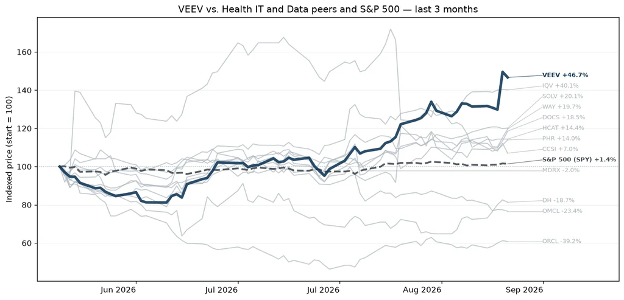

#### Earnings Call Summary

Veeva reported strong Q2 2027 results with total revenue of $928M, outperforming expectations and driven by its best CRM quarter ever. Non-GAAP operating income reached $416M, underpinned by an accelerating position in AI and strong overall operational execution across key business areas.

#### At a Glance

- **Veeva Beats EPS and Revenue Estimates:** Veeva Systems reported a reported revenue of $927.96 million, beating the estimated revenue of $905.26 million, alongside an adjusted EPS of $2.35 which outperformed the consensus expectation of $2.22.
- **Strong Performance In Subscription Metrics:** Subscription services revenue reached $766.8 million, showing a 16.3% increase year-over-year from $659.2 million and maintaining a strong growth pattern driven by expansive commercial and R&D cloud portfolio adoptions.
- **Management Raises Full-Year Fiscal Guidance:** Veeva raised its full-year fiscal 2027 revenue guidance to between $3.682 billion and $3.687 billion and lifted its adjusted EPS projection to a range of $9.05 to $9.21.
- **Vault CRM Achieves Record Milestones:** The quarter marked Vault CRM's best performance to date, securing commitments from three additional top-20 biopharma companies—including Eli Lilly, Biogen, and Regeneron—bringing its total to 12 out of the top 20.
- **Accelerating AI Development via Falcon:** The company's agentic AI labor platform, Veeva Falcon, saw rapid development momentum with five early adopters and remains safely on track for its initial deployments later this year.
- **Stock Surges and Analysts Respond:** Following the impressive financial beat and raised outlook, Veeva's shares surged by over 11% in pre-market trading as major analysts across multiple institutions actively lifted their price targets.

#### Key Moments from the Call

- **6m 2s — Agentic Labor Transformation via Veeva Falcon:** Veeva Falcon introduces a new agentic labor category distinct from traditional cloud software. This structural shift shifts the buying conversation directly to business unit leaders rather than IT departments, paving the way for faster deployment and immediate compliance and cost-saving advantages.
- **15m 41s — Salesforce CRM Win-Back Opportunities:** Management expressed high confidence in winning back top-20 pharma customers who previously selected Salesforce, citing significant delays and implementation struggles in those rival projects. Veeva's backstop expiration in 2029 is driving critical, actionable backup planning among these accounts.
- **27m 21s — Aspen Internal Startup Disruption:** Veeva's new Aspen initiative targets the broader horizontal CRM market with a highly simplified, AWS-like predictable pricing model ($50/user/month). Aspen leverages AI to eliminate heavy data entry and aims to disrupt incumbent vendors through lower, more transparent costs.
- **45m 22s — The Strategic IQVIA Partnership Reset:** One year after settling and partnering with IQVIA, leadership reported outstanding collaboration that has dramatically reduced friction for joint customers. The integration of data, software, and services between the two major industry players is functioning as a core growth driver for AI outcomes.

### HealthEquity (HQY) +9.5%

**Reported:** August 27, 2026 · [Google Finance earnings page](https://www.google.com/finance/quote/HQY:NASDAQ?tab=earnings&hl=en)

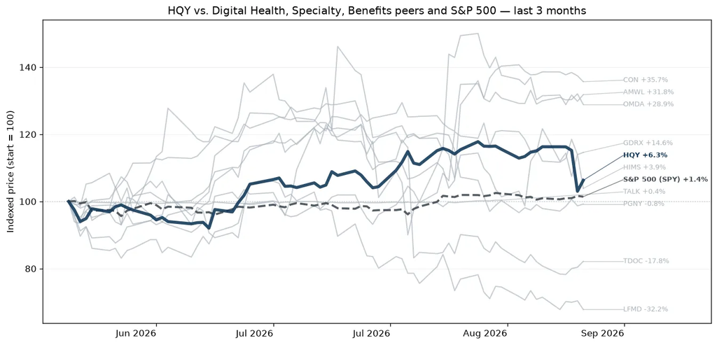

#### Earnings Call Summary

HealthEquity delivered accelerated Q2 2027 revenue growth of 8% year-over-year to a record $350.7M and non-GAAP EPS of $1.24, beating estimates. Total HSA assets increased 14%, total HSAs grew 8% to 10.7 million, and new HSAs from sales rose 24% year-over-year, marking a record outside of the open enrollment period.

#### At a Glance

- **HealthEquity Tops EPS and Revenue:** HealthEquity reported Q2 2027 reported adjusted EPS of $1.24, which outperformed the estimated adjusted EPS of $1.193. Reported revenue reached $350,732,000, slightly topping the estimated revenue of $349,231,240.
- **HSA Metrics Show Substantial Growth:** Total Health Savings Accounts (HSAs) grew 8% year-over-year to a record 10.7 million. Additionally, HSA invested assets climbed 28% year-over-year, showcasing deepening member participation compared to prior quarters.
- **Fiscal 2027 Topline Guidance Lifted:** Management raised its full-year fiscal 2027 revenue guidance to a range of $1.411 billion to $1.421 billion, up from the prior outlook of $1.410 billion to $1.420 billion. However, full-year adjusted EPS guidance was maintained at $4.66 to $4.73, which matched consensus expectations.
- **AI Implementations Lower Service Costs:** The company successfully deployed technology and AI-driven automation to achieve record operating leverage. This led to a 25% year-over-year decline in human-handled calls and allowed AI to resolve 85% of routine chat inquiries.
- **Market Reacts via Sell-the-Beat Trend:** Despite delivering a record-setting quarter with record margins and higher-than-expected earnings, shares of HealthEquity fell roughly 11% following the announcement. Investors expressed disappointment that the raised full-year guidance range only matched, rather than exceeded, Wall Street forecasts.

#### Key Moments from the Call

- **6m 56s — Marketplace and App Expansion:** The Consumer Marketplace reached 14,000 active members, boosted by Health Savings Days campaigns. A consolidated next-generation app is launching soon, establishing high-margin, organic growth channels that increase lifetime member value without rising acquisition costs.
- **9m 53s — AI Efficiency Drives Margin Beats:** AI automation reduced human-handled calls by 25% year-over-year, delivering a record 48% adjusted EBITDA margin. Investors will appreciate this concrete evidence of AI driving scalable cost savings and bottom-line expansion.
- **15m 14s — HSA Cash Yield & Hedging Strategy:** Management locked in long-term treasury yields and initiated complex enhanced rate hedges to reduce interest rate sensitivity, offering investors greater visibility and stability regarding custodial revenue amid macro interest rate fluctuations.
- **17m 11s — Full-Year 2027 Guidance Raised:** Management raised its fiscal 2027 outlook across revenue, net income, and adjusted EBITDA, signaling strong execution and operational momentum that will please investors looking for reliable, upwardly revised growth metrics.

## Company Overviews

### UnitedHealth (UNH)

*Payers · $380.1B · 3m +3.3% · 12m +26.8% · 24m -33.4%*

[Google Finance](https://www.google.com/finance/quote/UNH:NYSE?tab=earnings&hl=en)

Diversified healthcare company operating UHC insurance businesses and the Optum health services platform.

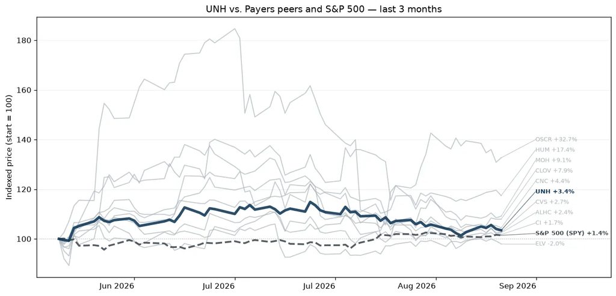

UnitedHealth Group is one of the largest private health insurers and provides medical benefits to about 51 million members globally, including 1 million outside the US as of December 2025. As a leader in employer-sponsored, self-directed, and government-backed insurance plans, UnitedHealth has obtained massive scale in medical insurance. Along with its insurance assets, UnitedHealth's Optum franchises help create a healthcare services colossus that spans everything from pharmaceutical benefits to providing outpatient care and analytics to affiliates and third parties.

### CVS Health (CVS)

*Payers · $135.1B · 3m +2.3% · 12m +27.2% · 24m +62.6%*

[Google Finance](https://www.google.com/finance/quote/CVS:NYSE?tab=earnings&hl=en)

Healthcare retail ecosystem.

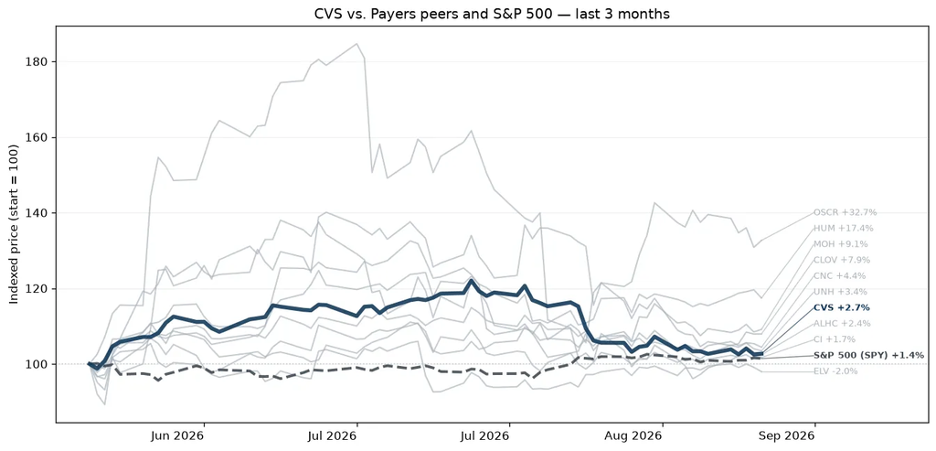

CVS Health offers a diverse set of healthcare services. Its roots are in its retail pharmacy operations, where it operates around 9,000 stores primarily in the US. CVS is also a large pharmacy benefit manager (acquired through Caremark), processing about 2 billion adjusted claims annually. It operates a top-tier health insurer (acquired through Aetna) through which it serves about 27 million medical members. The acquisition of Oak Street Health added primary care services to the mix, which could have significant synergies with all existing business lines.

### Humana (HUM)

*Payers · $43.7B · 3m +26.2% · 12m +27.0% · 24m +8.8%*

[Google Finance](https://www.google.com/finance/quote/HUM:NYSE?tab=earnings&hl=en)

Large payer, Medicare and Medicare Advantage focused.

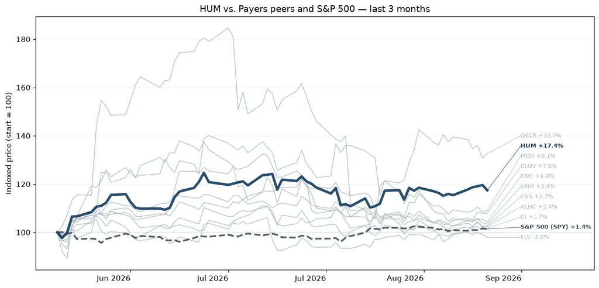

Humana is one of the largest private health insurers in the US, and the firm has built a niche specializing in government-sponsored programs, with nearly all its medical membership stemming from Medicare, Medicaid, and the military's Tricare program. Beyond medical insurance, the company provides other healthcare services, including primary-care services, at-home services, and pharmacy benefit management.

### Oscar Health (OSCR)

*Payers · $9.4B · 3m +37.1% · 12m +82.9% · 24m +66.5%*

[Google Finance](https://www.google.com/finance/quote/OSCR:NYSE?tab=earnings&hl=en)

Tech-focused payer with large exposure to exchange products and ICHRAs.

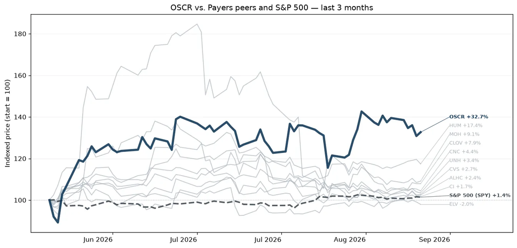

Oscar Health Inc is a healthcare technology company built around a full stack technology platform and a relentless focus on serving its members. It offers Individual & Family plans and health technology solutions that power the healthcare industry. Oscar operates as one segment to sell insurance to individuals, families and employees through the federal and state-run healthcare exchanges formed in conjunction with the Patient Protection and Affordable Care Act (ACA) and leverages its technology platform to provide services via its Oscar offering.

### Molina Healthcare (MOH)

*Payers · $10.2B · 3m +15.2% · 12m +10.6% · 24m -42.8%*

[Google Finance](https://www.google.com/finance/quote/MOH:NYSE?tab=earnings&hl=en)

Managed-care company providing health insurance through government programs.

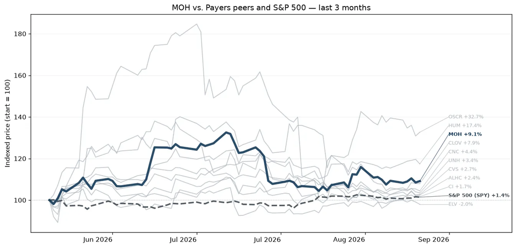

Molina Healthcare Inc provides medical insurance plans through Medicaid, the individual exchanges, and Medicare. The company operates in four reportable segments consisting of: 1) Medicaid; 2) Medicare; 3) Marketplace; and 4) Other. It manages health benefit risks for more than 5 million people, with more than 85% of those members coming through contracts with state governments for their Medicaid programs. Medicaid contracts in four states-California, New York, Texas, and Washington-account for over half of its enrollees.

### Cigna (CI)

*Payers · $73.7B · 3m +0.5% · 12m -7.3% · 24m -22.9%*

[Google Finance](https://www.google.com/finance/quote/CI:NYSE?tab=earnings&hl=en)

Employer-focused health insurance company.

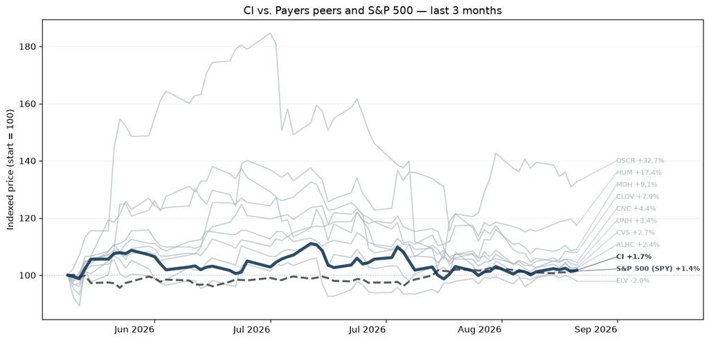

Cigna primarily provides pharmacy benefit management and health insurance services. Its PBM and specialty pharmacy services, which were greatly expanded by its 2018 merger with Express Scripts, are mostly sold to health insurance plans and employers. Its largest PBM contract is with the Department of Defense, and it recently won a multiyear deal with top-tier insurer Centene. In health insurance and other benefits, Cigna primarily serves employers through self-funding arrangements, and the company operates mostly in the US with 16 million US and 2 million international medical members covered as of December 2025.

### Elevance (ELV)

*Payers · $81.5B · 3m +0.3% · 12m +23.8% · 24m -29.2%*

[Google Finance](https://www.google.com/finance/quote/ELV:NYSE?tab=earnings&hl=en)

Health insurance company, previously named Anthem.

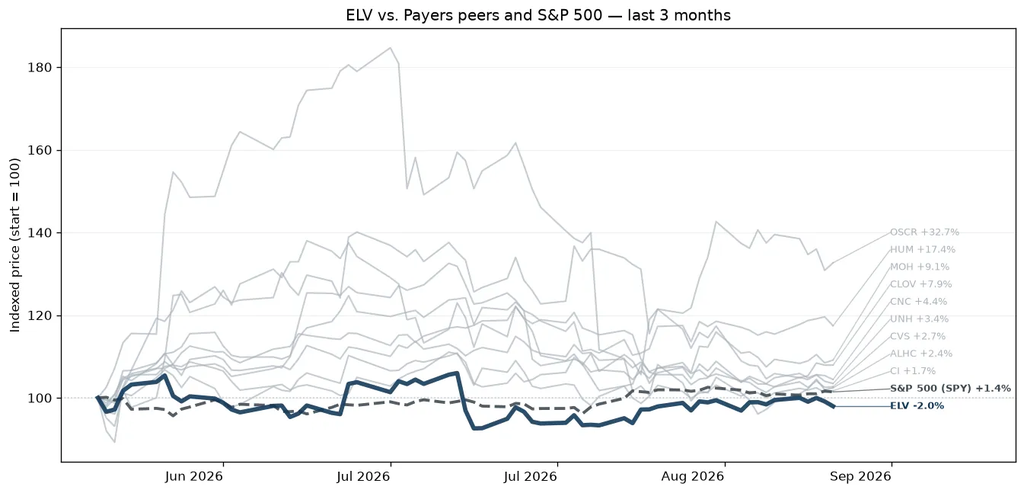

Elevance Health remains one of the leading health insurers in the US, providing medical benefits to 45 million medical members at the end of 2025. The company offers employer, individual, and government-sponsored coverage plans. Elevance differs from its peers in its unique position as the largest single provider of Blue Cross Blue Shield branded coverage, operating as the licensee for the Blue Cross Blue Shield Association in 14 states. Through acquisitions, such as the Amerigroup deal in 2012 and MMM in 2021, Elevance's reach expands beyond those states in government-sponsored programs, such as Medicaid and Medicare Advantage plans, too. It is also an emerging player in pharmacy benefit management and other healthcare services.

### Clover Health (CLOV)

*Payers · $2.2B · 3m +6.3% · 12m +61.5% · 24m +60.8%*

[Google Finance](https://www.google.com/finance/quote/CLOV:NASDAQ?tab=earnings&hl=en)

American healthcare company company providing Medicare Advantage insurance plans.

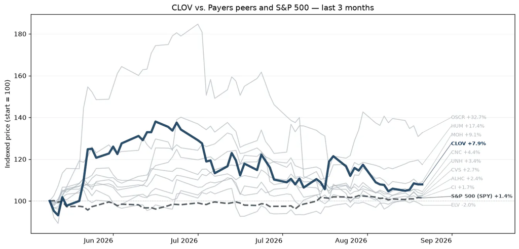

Clover Health Investments Corp is a healthcare technology company. It focuses on empowering Medicare physicians to proactively manage chronic diseases through its proprietary software platform, Clover Assistant. This cloud-based solution provides personalized insights to physicians, enabling early detection and management of chronic conditions. It operates in one segment: Insurance, through which it offers PPO and HMO plans to Medicare Advantage members in several states.

### Centene (CNC)

*Payers · $30.7B · 3m +8.6% · 12m +123.0% · 24m -17.9%*

[Google Finance](https://www.google.com/finance/quote/CNC:NYSE?tab=earnings&hl=en)

Health insurance for government and privately insured healthcare programs.

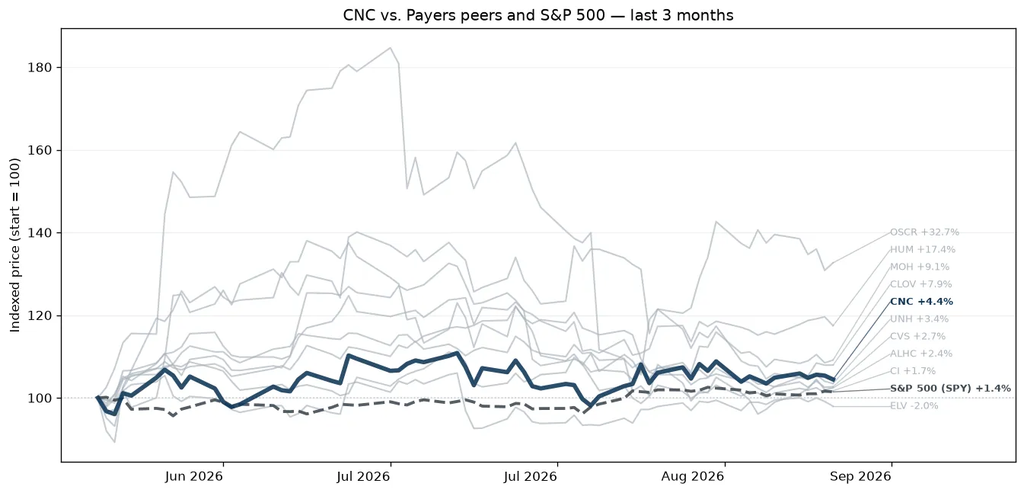

Centene is a managed care organization that focuses on government-sponsored healthcare plans, including Medicaid, Medicare, and the individual exchanges. Centene served 20 million medical members as of December 2025, mostly in Medicaid (about 64% of membership), the individual exchanges (about 28%), and Medicare (about 5%). The company also provides Medicare Part D pharmaceutical plans.

### Alignment Health (ALHC)

[Google Finance](https://www.google.com/finance/quote/ALHC:NASDAQ?tab=earnings&hl=en)

Tech-enabled Medicare Advantage Company.

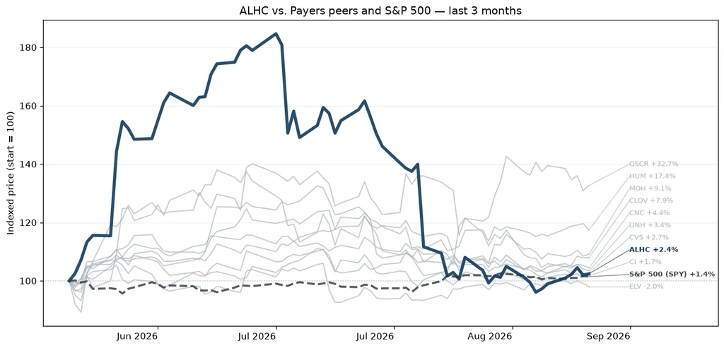

Alignment Healthcare Inc is a next-generation, consumer-centric platform that is revolutionizing the healthcare experience for seniors through Medicare Advantage plans. These plans are marketed and sold direct-to-consumer, allowing seniors to select the manner in which customers receive healthcare coverage and services on an annual basis. The company combines a technology platform and clinical model for more effective health outcomes.

### HCA Healthcare (HCA)

*Health System Providers · $87.2B · 3m +10.4% · 12m +3.4% · 24m +5.6%*

[Google Finance](https://www.google.com/finance/quote/HCA:NYSE?tab=earnings&hl=en)

Largest for-profit hospital and outpatient care operator in the United States.

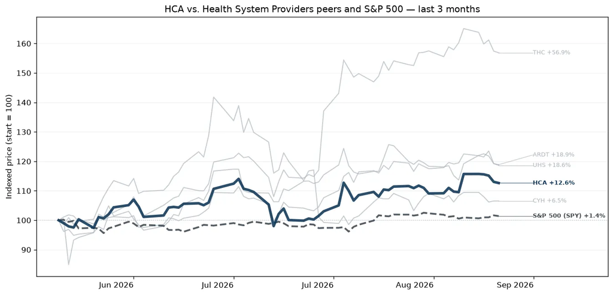

HCA Healthcare is a Nashville-based healthcare provider organization operating the largest collection of acute-care hospitals in the United States. As of December 2025, the firm owned and operated 190 hospitals and over 2,500 outpatient facillities across 19 states and a small foothold in the United Kingdom.

### Tenet Health (THC)

*Health System Providers · $20.5B · 3m +52.2% · 12m +44.7% · 24m +60.9%*

[Google Finance](https://www.google.com/finance/quote/THC:NYSE?tab=earnings&hl=en)

Diversified healthcare provider with hospitals and a leading ambulatory surgery center platform through USPI.

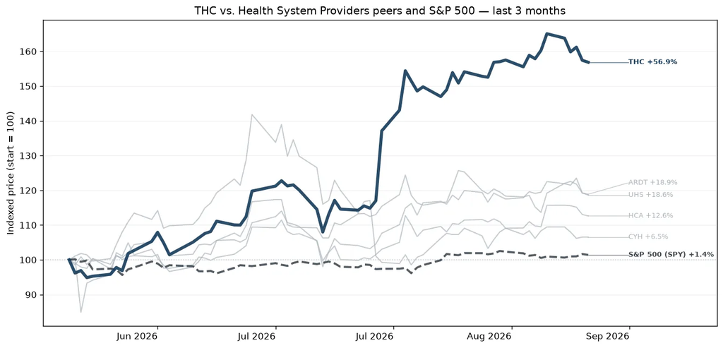

Tenet Healthcare is a Dallas-based healthcare services organization. It operates acute and specialty hospitals (50 as of December 2025) and hundreds of ambulatory surgery centers and other outpatient facilities across the US, primarily in the South. Through its Conifer segment, Tenet also provides revenue cycle management solutions.

### Universal Health Services (UHS)

*Health System Providers · $10.2B · 3m +17.5% · 12m -5.5% · 24m -27.9%*

[Google Finance](https://www.google.com/finance/quote/UHS:NYSE?tab=earnings&hl=en)

Hospital operator with significant acute care and behavioral health business.

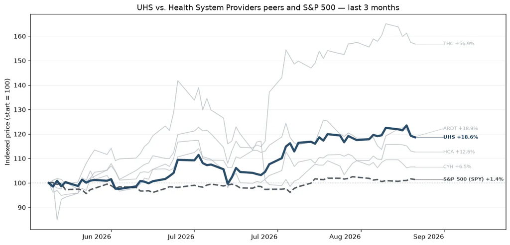

Universal Health Services Inc offers healthcare services through its behavioral health centers, acute care hospitals, and related outpatient facilities. As of late 2025, the company operated 346 inpatient behavioral health centers, 29 acute care hospitals, and many supportive outpatient facilities. Its operations are concentrated in the U.S, particularly in Nevada (21% of 2025 operating profits), Texas (19%), and California (13%), although it does have some exposure to the UK behavioral health market (6% of 2025 sales) too. While its acute care services account for over 55% of revenue, the behavioral health centers sport higher margins and account for over 55% of pretax profits.

### Community Health Systems (CYH)

*Health System Providers · $417.4M · 3m +7.7% · 12m +6.2% · 24m -46.2%*

[Google Finance](https://www.google.com/finance/quote/CYH:NYSE?tab=earnings&hl=en)

Operator of community hospitals primarily serving non-urban and regional markets.

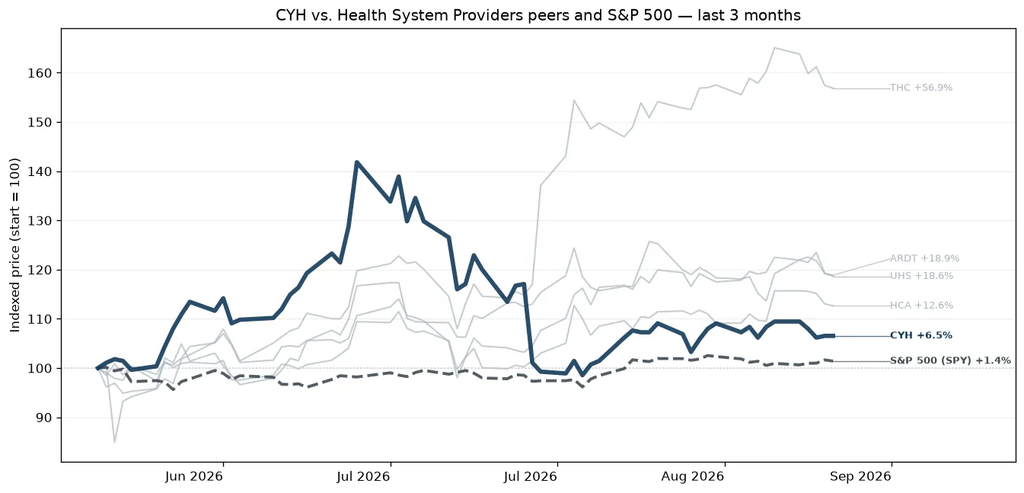

Community Health Systems Inc is a publicly owned hospital operator in the United States. The company also owns four home health agencies and provides management and consulting services to independent hospitals. The firm derives revenue through a broad range of general and specialized hospital healthcare services and outpatient services.

### Ardent Health Partners (ARDT)

*Health System Providers · $1.5B · 3m +18.7% · 12m -13.6% · 24m -44.7%*

[Google Finance](https://www.google.com/finance/quote/ARDT:NYSE?tab=earnings&hl=en)

Regional hospital operator focused on integrated health systems across mid-sized US markets.

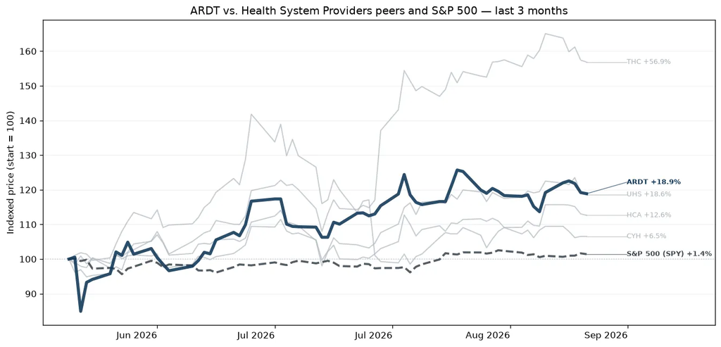

Ardent Health Inc is a provider of healthcare in growing mid-sized urban communities across the U.S and operating in eight growing mid-sized urban markets across six states Texas, Oklahoma, New Mexico, New Jersey, Idaho, and Kansas. The main focus on people and investments in services and technologies.

### The Ensign Group (ENSG)

*Inpatient Non-Acute Providers · $10.4B · 3m +3.2% · 12m +0.7% · 24m +14.3%*

[Google Finance](https://www.google.com/finance/quote/ENSG:NASDAQ?tab=earnings&hl=en)

Leading operator of skilled nursing facilities, rehabilitation centers, and senior-care services.

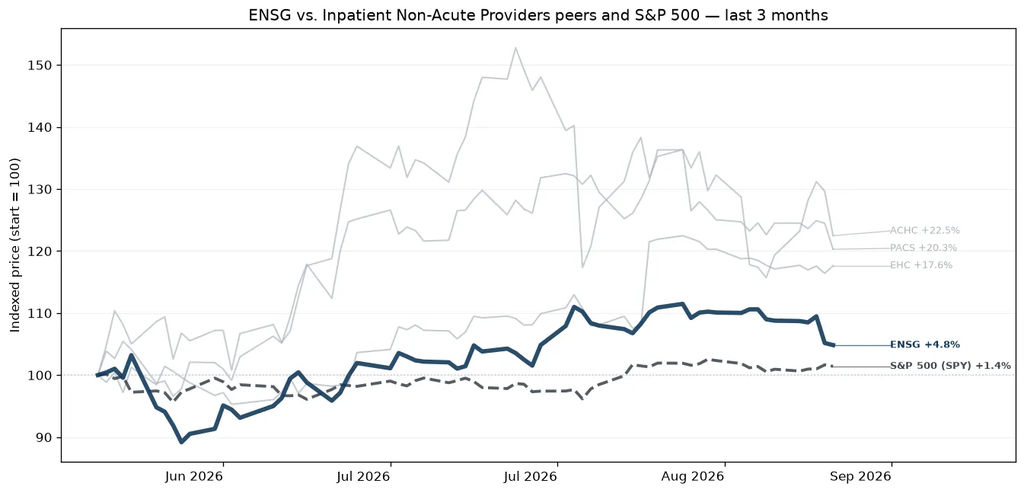

Ensign Group Inc provides post-acute healthcare services in the United States. Its regional subsidiaries oversee skilled nursing, assisted living, home health and hospice, mobile ancillary, and urgent care operations. Medicare and Medicaid programs contribute majority of revenue received for Ensign's services. The firm operates through two segments, Skilled services, and Standard Bearer. The skilled services segment includes the operation of skilled nursing facilities and rehabilitation therapy services. The Standard Bearer segment comprises of properties owned by the company through its captive REIT and leased to skilled nursing and assisted living operations. The majority of the revenue is generated from the skilled services segment.

### Acadia Healthcare (ACHC)

*Inpatient Non-Acute Providers · $2.8B · 3m +23.1% · 12m +24.3% · 24m -65.2%*

[Google Finance](https://www.google.com/finance/quote/ACHC:NASDAQ?tab=earnings&hl=en)

Largest provider of behavioral health and addiction treatment services.

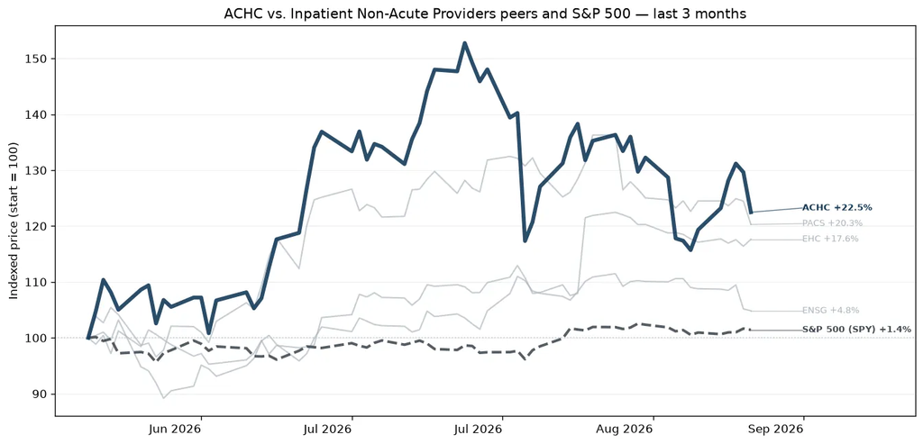

Acadia Healthcare Co Inc acquires and develops behavioral healthcare facilities. Its facilities and services are classified into the following categories: acute inpatient psychiatric facilities; specialty treatment facilities; CTCs; and residential treatment centers. In which Acute inpatient psychiatric facilities contribute the majority of revenue in the United States. The Company has one reportable segment, behavioral healthcare services. The behavioral healthcare services segment provides inpatient and outpatient behavioral healthcare services.

### Encompass Health (EHC)

*Inpatient Non-Acute Providers · $11.0B · 3m +14.2% · 12m -0.7% · 24m +29.9%*

[Google Finance](https://www.google.com/finance/quote/EHC:NYSE?tab=earnings&hl=en)

In-patient post-acute rehabilitation services.

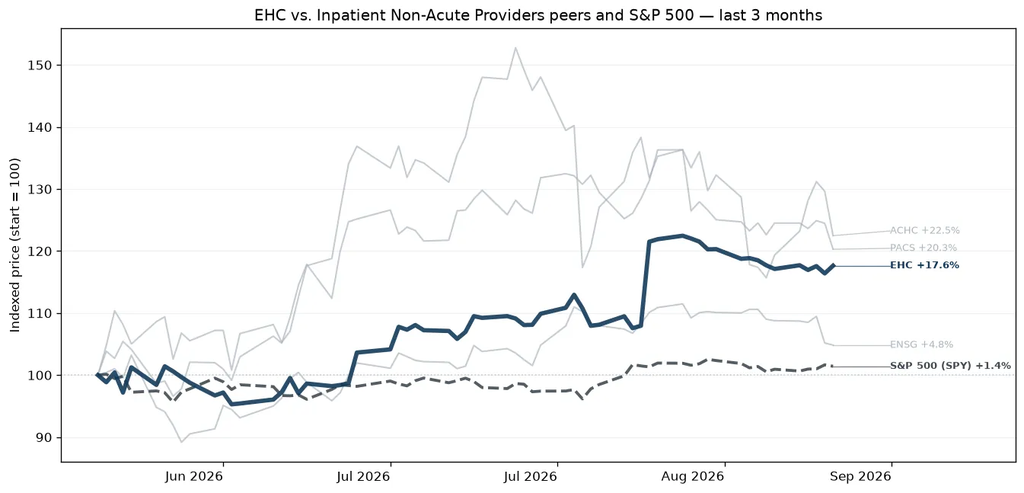

Encompass Health Corp provides post-acute healthcare services in the United States through a network of inpatient rehabilitation hospitals, which is the company's sole segment. Inpatient rehabilitation contributes the majority of the firm's revenue and provides specialized rehabilitative treatment through a network of inpatient hospitals. The company's inpatient rehabilitation hospitals provide a higher level of rehabilitative care to patients who are recovering from conditions such as stroke and other neurological disorders, cardiac and pulmonary conditions, brain and spinal cord injuries, complex orthopedic conditions, and amputations.

### PACS Group (PACS)

*Inpatient Non-Acute Providers · $7.3B · 3m +16.6% · 12m +267.3% · 24m +7.8%*

[Google Finance](https://www.google.com/finance/quote/PACS:NYSE?tab=earnings&hl=en)

Post-acute care and skilled nursing company.

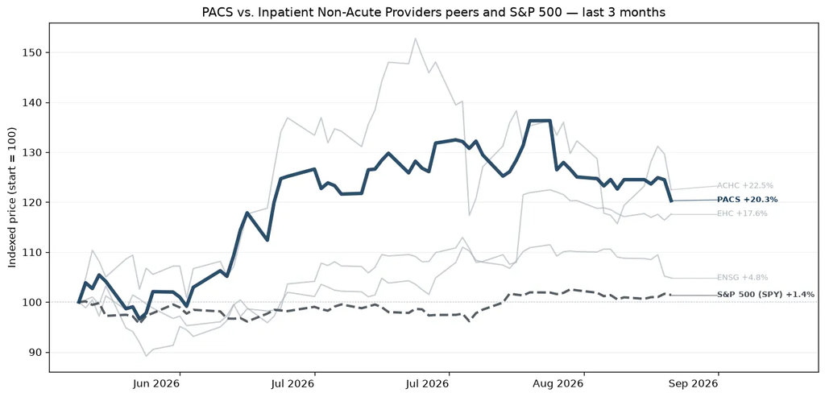

PACS Group Inc is a post-acute healthcare company mainly focused on delivering skilled nursing care through a portfolio of independently operated facilities. The post-acute care ecosystem serves individuals who need additional help recuperating from acute conditions, illnesses, or serious medical procedures after getting discharged from the hospital. It also provides senior care, assisted living, and independent living options in some of the communities. The company has one reportable segment.

### Healthpeak properties (DOC)

*Health Care Real Estate · $15.1B · 3m +9.5% · 12m +16.8% · 24m -5.9%*

[Google Finance](https://www.google.com/finance/quote/DOC:NYSE?tab=earnings&hl=en)

Healthcare industry real estate investment trust focused on outpatient medical offices, life science properties, an senior housing.

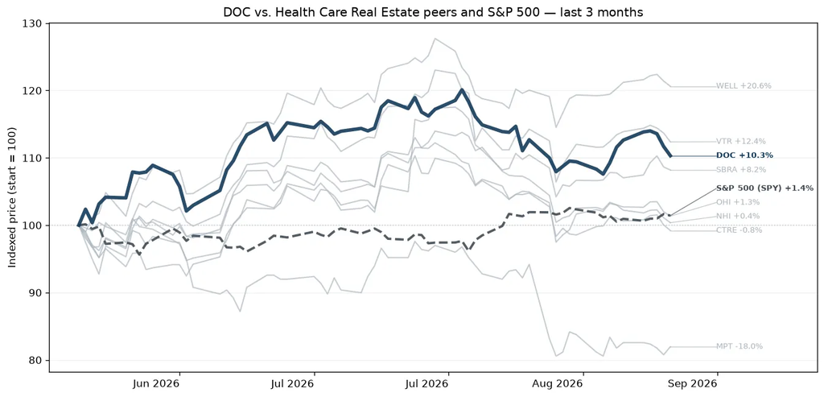

Healthpeak owns a diversified healthcare portfolio of approximately 700 in-place properties spread across mainly medical office and life science assets, plus a handful of senior housing, hospital, and skilled nursing/post-acute care assets, as well.

### Ventas, Inc (VTR)

*Health Care Real Estate · $48.0B · 3m +8.8% · 12m +34.9% · 24m +47.8%*

[Google Finance](https://www.google.com/finance/quote/VTR:NYSE?tab=earnings&hl=en)

Real estate investment trust focused on ownership and management of senior housing, research, medicine office buildings, and healthcare facilities.

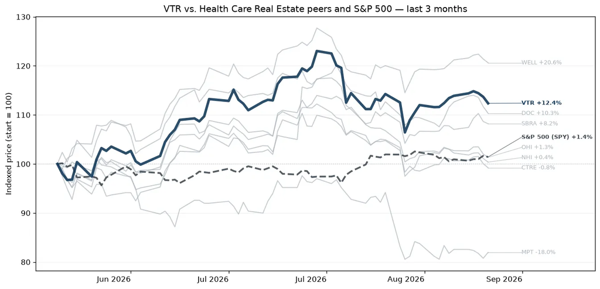

Ventas owns a diversified healthcare portfolio of almost 1,400 in-place properties spread across the senior housing, medical office, hospital, life science, and skilled nursing/post-acute care. The portfolio includes almost 100 properties in Canada and the United Kingdom as the company looks for additional investment opportunities in countries with mature healthcare systems that operate similarly to the United States. The firm also owns mortgages and other loans, contributing about 1% of net operating income.

### Medical Properties Trust (MPT)

*Health Care Real Estate · $2.8B · 3m -20.0% · 12m n/a · 24m n/a*

[Google Finance](https://www.google.com/finance/quote/MPT:NYSE?tab=earnings&hl=en)

Real estate investment trust for healthcare facilities in the US and Europe.

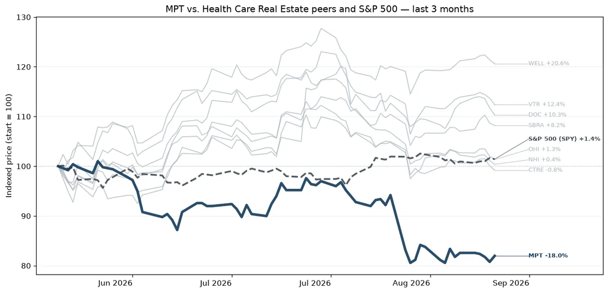

Medical Properties Trust Inc acquires and develops net-leased healthcare facilities. Its investments in healthcare real estate, other loans, and any investments in tenants are considered a single reportable segment. Its business strategy is to acquire and develop healthcare facilities and lease the facilities to healthcare operating companies under long-term net leases, which require the tenant to bear of the costs associated with the property. The group's geographic areas are the United States, the United Kingdom, and All other countries.

### National Health Investors (NHI)

*Health Care Real Estate · $3.7B · 3m -1.7% · 12m -8.0% · 24m -11.5%*

[Google Finance](https://www.google.com/finance/quote/NHI:NYSE?tab=earnings&hl=en)

Healthcare REIT focused on senior housing, skilled nursing, and long-term care properties.

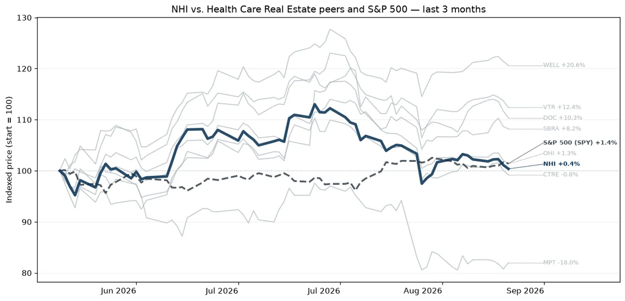

National Health Investors Inc is a self-managed REIT that owns, leases, operates, and finances the development of senior housing communities and medical facilities. It operates through two segments: Real Estate Investments and Senior Housing Operating Portfolio (SHOP). The Real Estate Investments segment, which generates the majority of revenue, includes real estate leases, mortgages, and other notes receivable related to independent living facilities, assisted living facilities, entrance fee communities, senior living campuses, skilled nursing facilities, and a hospital. The SHOP segment consists of ventures that own and operate independent living facilities. The company's revenues are derived from rental income, interest and other income, and resident fees and services.

### Omega Healthcare Investors (OHI)

*Health Care Real Estate · $15.1B · 3m -1.6% · 12m +8.0% · 24m +16.3%*

[Google Finance](https://www.google.com/finance/quote/OHI:NYSE?tab=earnings&hl=en)

Healthcare REIT healthcare REIT focused on skilled nursing and assisted living facilities.

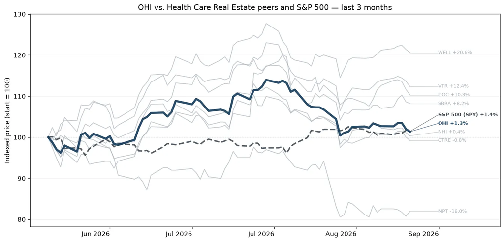

Omega Healthcare Investors Inc is a real estate investment trust that invests in healthcare-related real estate properties located in the United States (U.S.), the United Kingdom (U.K.), and Canada. The company's objective is to provide attractive returns to investors while serving as the preferred capital partner to its third-party healthcare operating companies and affiliates, as well as other third-party healthcare operators, allowing them to focus on delivering a high level of care to their resident patients. Omega's investment portfolio mainly consists of skilled nursing facilities, assisted living facilities (ALFs), including care homes in the U.K., independent living facilities, rehabilitation and acute care facilities, and continuing care retirement communities.

### Welltower (WELL)

*Health Care Real Estate · $166.9B · 3m +15.9% · 12m +41.5% · 24m +97.3%*

[Google Finance](https://www.google.com/finance/quote/WELL:NYSE?tab=earnings&hl=en)

Largest healthcare REIT, focused on senior housing, outpatient medical, and wellness-oriented healthcare properties.

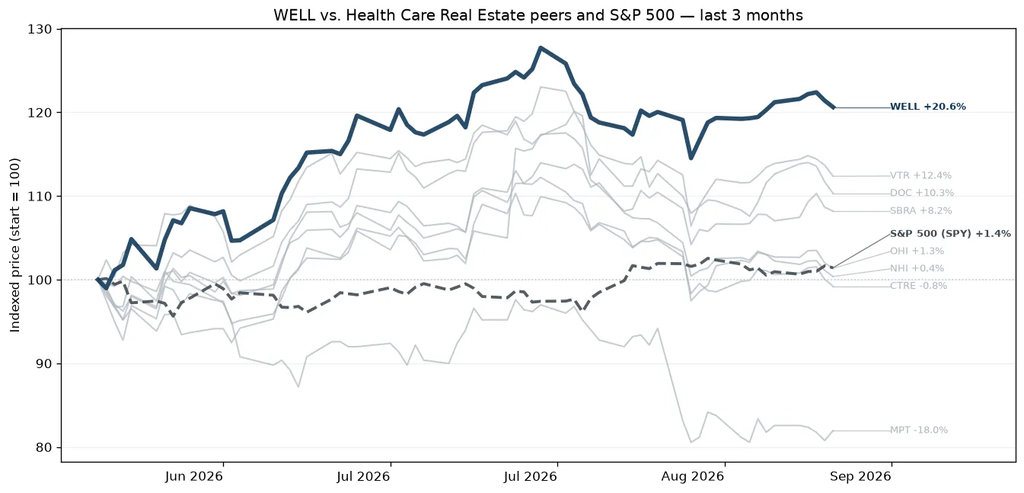

Welltower owns a diversified healthcare portfolio of 2,800 in-place properties spread across the senior housing, medical office, and skilled nursing/postacute care sectors. The portfolio includes over 900 properties in Canada and the United Kingdom as the company looks for additional investment opportunities in countries with mature healthcare systems that operate similarly to that of the United States.

### CareTrust REIT (CTRE)

*Health Care Real Estate · $9.6B · 3m -4.4% · 12m +13.4% · 24m +30.6%*

[Google Finance](https://www.google.com/finance/quote/CTRE:NYSE?tab=earnings&hl=en)

Healthcare REIT focused on skilled nursing, senior housing, and other post-acute care facilities.

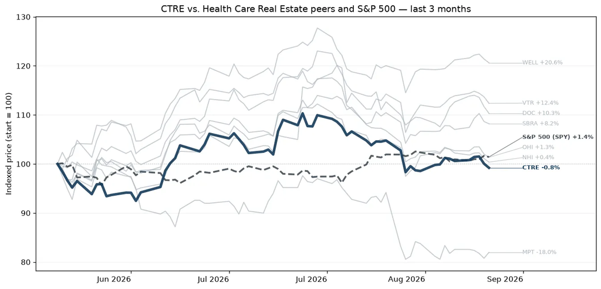

CareTrust REIT Inc is a self-administered, publicly traded REIT engaged in the ownership, acquisition, financing, development, and leasing of skilled nursing, seniors housing, and other healthcare-related properties. The company has one reportable segment consisting of investments in healthcare-related real estate assets. It generates revenues by leasing healthcare-related properties to healthcare operators under triple-net lease arrangements, in which the tenant is solely responsible for property-related costs. The company operates in Domestic and Foreign markets, with the majority of revenue coming from Domestic operations.

### Sabra Health Care REIT (SBRA)

*Health Care Real Estate · $5.3B · 3m +3.6% · 12m +7.8% · 24m +21.0%*

[Google Finance](https://www.google.com/finance/quote/SBRA:NASDAQ?tab=earnings&hl=en)

healthcare REIT focused on skilled nursing, senior housing, and behavioral health properties.

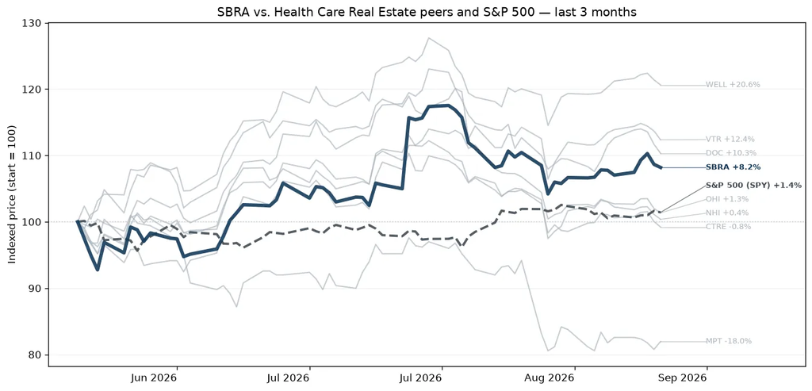

Sabra Health Care REIT Inc is a healthcare facility real estate investment trust. The company operates one segment that owns and invests in healthcare real estate. All of the company's revenue is generated in the United States. Sabra's operations consist of nursing facilities, assisted living centers, and mental health facilities.